# Stephanie’s Housing Request

W02 Analysis

Andrew Seaman

Jan 21, 2025

```r
knitr::opts_chunk$set(echo = TRUE, cache = FALSE, clean = TRUE)
```

```r
rent <- read_csv("../Data/Rent.csv")
```

## Background

**Who is Stephanie?**

Stephanie[^1] is a student that will be starting school at BYU-Idaho next semester. Suppose she sent you the following email.

**Letter From Stephanie**

“Hi. My name is Stephanie. I would like to learn about what housing options I have for living at BYU-Idaho[^2] next semester. It will be my first semester there, so I would like to find something that is close to campus and around $300 a month in rent. I’m not too picky on roommates, but I would like somewhere that has a lot of people around so I can get to know as many people as possible. Thanks in advance!”

## Response

*Dear Stephanie,*

Exciting times are ahead for you at BYU—Idaho!

To recap your housing criteria:

- BYUI Approved Women’s Housing
- Close to campus
- Affordable housing at approximately $300/month ($1,200/semester).
- A social environment with a high number of residents.

Two quick notes about rent and residents:

- **Rent Payment Structure**: most apartment complexes in Rexburg require full payment for the semester (≈ four months, 14 weeks) upfront. Some, however, offer monthly or installment options with a small additional fee. In this analysis, rent will be listed per semester.
- **Housing Terminology:** If an apartment complex name includes “- WOMEN,” that means it has both men’s and women’s housing in separate, often adjacent, buildings. If it does not, then it is women-only housing.

The most suitable housing option for Stephanie will be a BYU–Idaho-approved women’s housing complex that is below $1,200 per semester and has more residents than the average housing complex, as a larger resident count will provide a stronger social environment.

If housing options that meet these conditions also have a positive public description about social engagement, then this hypothesis will be supported.

To filter out men’s housing and find housing that essentially costs less than $300/month is simple enough. The first level of complexity is deciding how one identifies a “good social environment”. The numerical factors available for consideration include total resident count, gender of demographic, distance to campus, and perhaps some more abstract factors. Certain assumptions must be made to make these factors meaningful however. We could choose to say high resident count means high social contact. Further, we might posit complexes with only female tenants aren’t as socially conducive as one where both male and female tenants are housed as dating is a big component of the typical college experience. This too would allow for smoother co-ed friend group formation. Lastly, many freshman don’t have cars and therefore value living relatively close to campus. This consideration could allow us to identify freshman preferred housing options which would place you living with peers in your same cohort of experience.

Lastly, it’s worth noting if the sequence of filters reduce the options too much the later mentioned factors may be dropped entirely from consideration. Alternatively, the first-applied filters can be loosened. For example, we might up the desired rent maximum to allow for a better overall search outcome.

## Analysis

```r
# DF 1: Apply no criteria (base data)
## Count the rows: # of housing options
opt1 <- nrow(rent)

# DF 2: Apply the 1st and 2nd criteria (gender/rent)
rent2 <- rent %>% filter(
    Gender == "F",                       # Approved Women’s Housing
    AvgFloorPlanCost <= 1200             # ≈ $300/month (or $1,200/semester)
  )

opt2 <- nrow(rent2) # Count the rows: # of housing options remaining

# Average Residents
avgResidents <- mean(rent$Residents)
round_avgResidents <- ceiling(avgResidents)

# DF 3.1: Apply the 3rd criteria (resident count)
rent3.1 <- rent2 %>% filter(
  Residents >= avgResidents   # Social environment (more residents than the mean)
  )

opt3 <- nrow(rent3.1) # Count the rows: # of housing options remaining
```

Starting with **110** complexes, after filtering out men’s housing and where rent is greater than $1200/semester only **16** housing options remain. Applying the third criteria, or where total residents is greater than the *average residents* (**140**) of all complexes **4** options remain.

```r
# DF 3.2: Select columns
rent3.2 <- rent3.1 %>%
  select(
    Name,
    AvgFloorPlanCost,
    MaxFloorPlanCost,
    Residents
  )

datatable(rent3.2, caption = "Prime Housing Options", options = list(
          dom = "t"
  ))
```

|  | Name | AvgFloorPlanCost | MaxFloorPlanCost | Residents |
| --- | --- | --- | --- | --- |
| 1 | BROOKLYN APARTMENTS | 995 | 995 | 144 |
| 2 | LA JOLLA - WOMEN | 1179 | 1179 | 210 |
| 3 | ROYAL CREST | 995 | 995 | 342 |
| 4 | SOMERSET APARTMENTS - WOMEN | 1200 | 1200 | 180 |

```r
# rent3_Select_Melt <- rent3_Select %>%
#     # Melt and transform the data
#     pivot_longer(
#       cols = -Name,                        # All columns except 'Name'
#       names_to = "Details",                # New column for melted data
#       values_to = "Value"                  # Values in a single column
#     ) %>%
#       pivot_wider(
#         names_from = Name,                   # Apartment names become column headers
#         values_from = Value                  # Values fill the new columns
#       )

# Display table (DF_2): melted subset data
# datatable(
#   rent3_Select_Melt,
#   options = list(
#     lengthMenu = c(4),
#     scrollX = TRUE,        # Enable horizontal scrolling
#     fixedColumns = TRUE,   # Enable fixed columns
#     columnDefs = list(
#       list(className = 'dt-left', targets = 0) # Align the first column to the left
#     )
#   )
# )
```

Here, Stephanie, you can use these three graphics to visually compare these numbers. Pay attention to the y-axis with the dollar values as the graphic to the far right varies from the others.

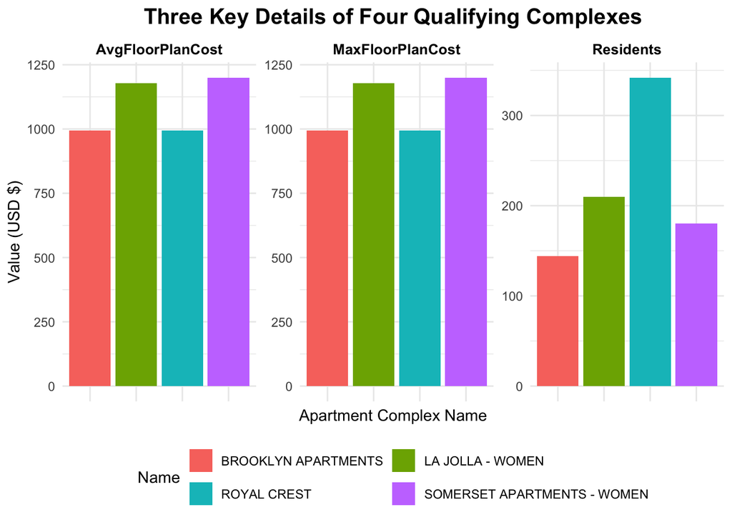

```r
# Define custom labels for each facet
facet_labels <- c(
  AvgFloorPlanCost = "Avg Floor Plan Cost (Per Semester)",
  MaxFloorPlanCost = "Max Floor Plan Cost (Per Semester)",
  Residents = "Number of Residents"
)

# DF 3.2_Long
rent3.2_long <- rent3.2 %>%
  pivot_longer(cols = AvgFloorPlanCost:Residents,
               names_to = "Detail",
               values_to = "Value")

# Plot with facet-specific labels
ggplot(rent3.2_long, aes(x = Name, y = Value)) +
  geom_bar(stat = "identity", aes(fill = Name), show.legend = TRUE) +
  facet_wrap(~ Detail,
             scales = "free_y",
             labeller = labeller(Detail = function(x) str_wrap(x, width = 20))) +  # Wrap text
  labs(title = "Three Key Details of Four Qualifying Complexes",
       x = "Apartment Complex Name",
       y = "Value (USD $)") +
  theme_minimal() +
  theme(
    plot.title = element_text(
      face = "bold",
      size = 15,
      hjust = 0.5,
      color = "black"
    ),
    strip.text = element_text(  # Apply text wrapping for facet titles
      size = 10,
      face = "bold",
      color = "black",
      lineheight = 1.2  # Adjust line spacing for better readability
    ),
    axis.text.x = element_blank(),
    axis.ticks.x = element_blank(),
    legend.position = "bottom"
  ) +
  guides(fill = guide_legend(nrow = 2, byrow = TRUE))
```

If these four options aren’t suitable you can instead browse the entire select of BYU—Idaho Approved Women’s and slightly adjusting your housing criteria to find the right fit.

In this complete list, all data collected is shown including pricing, parking spaces, even website links.

```r
# DF 4: Display subset data for Approved Women’s Housing
rent %>%
  filter(Gender == "F") %>%
  datatable(
    caption = "All Women's Housing Options",
    options = list(
      lengthMenu = list(
        c(1, 5, 15, 30, -1),  # -1 represents "All"
        c(1, 5, 15, 30, "All") # Labels for each option
      )
    ),
    extensions = "Responsive"
  )
```

|  | Name | Gender | Address | Phone | AvgFloorPlanCost | MaxFloorPlanCost | Residents | ParkingSpaces | Deposit | FloorPlanNumber | WebAddress | Latitude | Longitude | PublicDescription | CrowFlyMetersToMC | CrowFlyMetersToRicks |
| --- | --- | --- | --- | --- | --- | --- | --- | --- | --- | --- | --- | --- | --- | --- | --- | --- |
| 1 | ABBY LANE MANOR | F | 437 S 4TH W | (208) 643-3731 | 1200 | 1350 | 42 | 35 | 75 | 3 | www.abbylaneapartments.com | 43.81710724 | -111.7949519 | Abby Lane Manor is a women's complex offering spacious private and shared rooms that is just a ten minute walk from campus. Our girls enjoy amenities such as free laundry, personal vanities in each be… | 1013.45250687716 | 1122.73892409909 |
| 2 | ABRI APARTMENTS - WOMEN | F | 220 E 1ST S | (208) 417-7223 | 1660 | 1670 | 144 | 204 | 150 | 3 | liveabri.com | 43.82340456 | -111.7774263 | Deluxe &amp; Townhome Floorplans! Offering early bird special of $100 off! Upscale, modern finishes, state-of-the-art fitness center, fully equipped clubhouse, study rooms, courtyard with firepit &amp… | 685.719421907855 | 998.114322610954 |
| 3 | ALLEN'S SUNRISE VILLAGE - WOMEN | F | 48 W 2ND S | 208-356-3995 | 1225 | 1225 | 144 | 133 | 150 | 3 | www.sunrisevillageapts.com | 43.82275434 | -111.7857894 | Sale on multi-semester contracts happening now. Save up to $175 + FREE Laundry! We are well-known for our friendliness, two refridgerators, low prices, great location, our free laundry, reliable OPTIX… | 547.940773576173 | 945.30118183435 |
| 4 | AMERICAN AVENUE - WOMEN | F | 151 S 1ST E | 208-356-5097 | 1225 | 1225 | 138 | 110 | 150 | 3 | myamericanavenue.com | 43.8227079 | -111.779674 | At American Avenue we have several apartment layouts for you to make home. We are currently under renovation &amp; things are amazing! Our apartment homes have shared room or private room options next… | 525.534995518202 | 880.014318150109 |
| 5 | AT THE GROVE | F | 349 HARVARD AVE | 512-363-2396 | 1250 | 1250 | 6 | 6 | 150 | 1 | atthegroveapts.com | 43.81865937 | -111.7763239 | At The Grove is a spacious basement apartment, located just a stone's throw away from the east side of campus, and around the corner from the temple. Here you will enjoy the feeling of "home," in apar… | 496.662577261209 | 582.402605528998 |
| 6 | AUTUMN WINDS - WOMEN | F | 160 W 5TH S | (208) 356-0821 | 1725 | 1725 | 96 | 150 | 150 | 1 | www.rexburghousing.com/autumn-winds | 43.81599246 | -111.7884877 | Autumn Winds offers Private rooms with only 4 people per apartment! There are two bathrooms with 2 sinks each, so you will have your own vanity area. Each apartment has in-unit W/D, so you won't need … | 553.882039925135 | 588.197656526296 |
| 7 | AVONLEA - WOMEN | F | 175 W 3RD S | (208) 359-0920 | 1398.33 | 1725 | 66 | 54 | 80 | 6 | www.rexburgstudenthousing.com/new/property/13 | 43.81944123 | -111.789228 | Avonlea prides itself on being one of the most sought-after properties at BYU-I. You’ll enjoy the beautiful grounds for relaxing, games, or FHE parties and an amazing location so close to campus! Each… | 553.367426583124 | 812.134986535789 |
| 8 | BAYSIDE MANOR | F | 248 1/2 CORNELL AVE | 208-794-0652 | 985 | 985 | 8 | 8 | 90 | 1 | baysidemanor.blogspot.com | 43.82065271 | -111.7798457 | With its prime location close to the girls dorms and across the street from campus, you can get the off-campus experience and great location all at the same time. Bayside Manor is a basement apartment… | 325.111325094436 | 652.567329437239 |
| 9 | BIRCH PLAZA - WOMEN | F | 236 S 1ST W | (208) 359-8200 | 1352.5 | 1505 | 173 | 100 | 150 | 3 | www.rexburghousing.com/birch-plaza | 43.82093525 | -111.78819 | Some girls choose to spend all of their BYU-Idaho years living at Birch Plaza. That's how good it is. The wards are outstanding, and there's a sense of community that you'll find almost nowhere else. … | 535.853813010691 | 869.682528230362 |
| 10 | BIRCH WOOD I | F | 253 S 2ND W | (208) 359-8200 | 1370 | 1505 | 65 | 20 | 150 | 3 | www.rexburghousing.com/birch-plaza | 43.8203779 | -111.7891556 | Birch Plaza Premium is a very special place. The ward is outstanding, as are the residents. There's a hot tub and ample parking. A city park is one block away, and BYUI campus is half a block in the o… | 577.855024805305 | 876.649964289811 |

[output cut: 44 more lines]

```r
# DF 4: Get the public description for each qualifying complex (4)
rent4 <- rent3.1 %>%
  select(
    Name,
    PublicDescription,
    WebAddress
  )

name <- rent4$Name
description <- rent4$PublicDescription
link <- rent4$WebAddress

pfx_1 <- "http://"
pfx_2 <- paste0("www.", pfx_1)

for (i in seq_along(link)) {
  if (!startsWith(link[i], "http")) {
    link[i] <- paste0(pfx_1, link[i])
  } else if (!startsWith(link[i], "www")) {
    link[i] <- paste0(pfx_2, link[i])
  } else {
    link[i] <- "WebAddress not valid"
  }
}
```

Below you will find the public descriptions for each qualifying complex (4).

1. **[BROOKLYN APARTMENTS](http://craiglandhousing.com/new/property/1)**: Brooklyn Apartments is a wonderful place to live, study, meet new friends and grow. Living here makes socializing, getting to class and shopping easier as we are located in the heart of Rexburg and only one block from campus. Our new furniture and carpet offers quality and comfortable living at a great low price. Come by and check us out!
2. **[LA JOLLA - WOMEN](http://www.LaJollaRexburg.com)**: La Jolla is a mixed gender complex conveniently located one block north of campus. It’s close to campus, grocery stores, job opportunities on main street Rexburg, and many food places. You’ll find a BBQ area, basketball court, covered bike pavilion, high speed internet, a state of the art fitness room, piano room and a lounge with a fireplace, full kitchen, 70” Smart TV and games.
3. **[ROYAL CREST](http://WWW.ROYALCRESTAPARTMENTS.COM)**: If you are looking for affordable, comfortable, social living then Royal Crest is the place for you this semester. With our convenient location in Rexburg, you can be sure to be close to all the community and BYU-Idaho activities. With a serene and casual setting, you`re sure to feel at home with us.
4. **[SOMERSET APARTMENTS - WOMEN](http://www.rexburghousing.com/somerset)**: Somerset is located directly across the street from the heart of campus. These apartments had a major renovation completed in Fall 2015 for women. The wards are fantastic and is all contained within Somerset. It is an experience you will love! We have a piano room, weight room, and large lounge where you can spend time with your friends. Spaces fill up quickly-reserve your spot today!

I wish you the best of luck finding your first apartment! I remember mine warmly to this day.

See you around, Andrew Seaman

[^1]: **Stephanie** is a fictional character who is based on real experiences of many faculty and staff here at BYU-Idaho.
[^2]: [BYU-Idaho](https://www.byui.edu) is a 4-year university located in southeastern Idaho owned and sponsored by [The Church of Jesus Christ of Latter Day Saints](https://www.churchofjesuschrist.org/?lang=eng).